# Presidential Elections: 1.5

Sono Shah

2017-08-15

# Today’s Readings

- Chapter 5: Modern Campaign Strategies
- Chapter 13: Voter Choice

# Modern Campaign Strategy

- Campaigns try to mobilize supporters and persudade undecided voters
- Involves making decisions about whether to run, which issues to emphasize, what positions to take on issues, whether to attack the opposition, and how to allocate resources to different constituencies and media

# Developing a strategy

- The electorate can be divded into three groups: candidate’s base, opponent’s base, and the undecided
- Past election results + survey research make it possible to determine which poeple fall into each group

# Developing a strategy

- It is neither possible nor necessary to get the support of all peopel evewrywhere to win the election
- Once a campaign has ID’d who they need to win, they should act to do so

# Voter Targets

- How many **total** votes the campiagn belives will be cast in the election
- How many votes it will need **to win**
- How many votes **its candidate** can expect no matter what
- How many **persuadable** (swing) votes are out there

# Voter Targets

- Campaigns typically derive vote targets by examining data from recent comparable elections
- Build estimates for: a good candidate versus a bad candidate by looking at prior elections
- Similar process for swing votes

# Idea versus Identification

- Vote targets **do not** translate into individual targets
- We have an idea about **how many** voters can by swayed
- But, we don’t know **which** individuals are most likely to be persuaded.

# Profiling Voters

- In order to ID these voters, campaigns typically use surveys and focus groups, among other things.
- Surveys are mostly probablity samples
- focus groups are usually used as an in-depth follow up
- what are some differences?

# Microtargeting

- Campaign uses information gained from results of poll + focus groups to generate a guess of each person’s **persuadability**, in their file.
- They isolate specific voters for mailings, phone calls, or in-person visits

# Microtargeting

1. A “cookie,” or digital marker, is dropped on a user’s computer after the user visits a Web site or makes a purchase,
2. That profile is matched with offline data like what charities a person supports, what type of credit card a person has and what type of car he or she drives.

# Microtargeting

3. The political consultants then take a third step and match that data with voting records, including party registration and how often the person has voted in past election cycles, but not whom that person voted for.

# Obama Campaigns

- In 2008, Obama’s campaigns had enough data that they buy advertising on specific *bus routes* in select cities accross the country

# Deciding to run

- motivation to run
- resources to run
- staff to help
- opportunity

# Differences accross groups

- Why so few women hold elective office?
- Although women candidates are as likely to as male candidates to **win** elections, they are less likely to **run** in the first place (Lawless & Fox 2005)
- Others point to charateristics like risk assessment, time and resources, etc. (more on this next week)

# Issue Priorities

- What issues should a candidate emphasize?
- Think about 2016 election? What where their issue priorities?

# Median voter theorem

- How do they decide which position to take?
- Candidates seek to position themselves nearest to the voter that would provide the winning vote for them: the **median voter**

# Median voter theorem

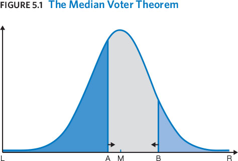

# It’s complicated

- candidates are constrained
- they neeed to appeal to different constituencies (donors, volunteers, activists, interest groups)
- appealing to a certain constituency might mean alienating another
- candidates might try to appeal to multiple groups by being intentionally vague

# It’s complicated

- It also assumes that voters know where they stand on issues
- and where the candidate stands on issues

# What influences voter choice?

- social identities
- party identification
- the performance of incumbents
- policy issues
- candidate traits

# Social identities

- often related to class background, ethnicity, or religion
- the party that best serves the interests ofa group may attract the enduring loyalty of its members
- examples?

# Party ID

- psychological attachment to a political party
- does not mean identification with particular political ideologies or opinions
- Examples of similar things?

# Incumbent Performance

- State of the economy
- when the economy is growing, voters are likely to reward the incumbent party

# Retrospective voting

- Are you better off now, than you were four years ago?
- sociotropic voting
- pocketbook voting
- through a partisan lens

# Policy Issues

- proximity voting
- voters choose the candidate whose views are closest or most proximate to theirs
- doesn’t seem to happen all that much
- as little as half of the electorate has the requsite opinions on issues with sufficient knowledfe of candidates’ views to engage in issue voting